# Risk Factor Analysis

## Outcome Variable

**Outcome Variable:** y_rate_len

## Predictor Variables

**Intervention Variable:** hhwealth_quart

**Adjustment Set:**

unadjusted

## Stratifying Variables

The analysis was stratified on these variable(s):

- agecat
- studyid
- country

## Data Summary

| agecat | studyid | country | hhwealth_quart | n_cell | n |
| --- | --- | --- | --- | --- | --- |
| 0-3 months | ki0047075b-MAL-ED | BANGLADESH | Wealth Q4 | 26 | 82 |
| 0-3 months | ki0047075b-MAL-ED | BANGLADESH | Wealth Q1 | 4 | 82 |
| 0-3 months | ki0047075b-MAL-ED | BANGLADESH | Wealth Q2 | 15 | 82 |
| 0-3 months | ki0047075b-MAL-ED | BANGLADESH | Wealth Q3 | 37 | 82 |
| 0-3 months | ki1017093b-PROVIDE | BANGLADESH | Wealth Q4 | 167 | 634 |
| 0-3 months | ki1017093b-PROVIDE | BANGLADESH | Wealth Q1 | 155 | 634 |
| 0-3 months | ki1017093b-PROVIDE | BANGLADESH | Wealth Q2 | 152 | 634 |
| 0-3 months | ki1017093b-PROVIDE | BANGLADESH | Wealth Q3 | 160 | 634 |
| 0-3 months | kiGH5241-JiVitA-3 | BANGLADESH | Wealth Q4 | 4632 | 20030 |
| 0-3 months | kiGH5241-JiVitA-3 | BANGLADESH | Wealth Q1 | 5102 | 20030 |
| 0-3 months | kiGH5241-JiVitA-3 | BANGLADESH | Wealth Q2 | 5294 | 20030 |
| 0-3 months | kiGH5241-JiVitA-3 | BANGLADESH | Wealth Q3 | 5002 | 20030 |
| 0-3 months | kiGH5241-JiVitA-4 | BANGLADESH | Wealth Q4 | 389 | 1805 |
| 0-3 months | kiGH5241-JiVitA-4 | BANGLADESH | Wealth Q1 | 450 | 1805 |
| 0-3 months | kiGH5241-JiVitA-4 | BANGLADESH | Wealth Q2 | 473 | 1805 |
| 0-3 months | kiGH5241-JiVitA-4 | BANGLADESH | Wealth Q3 | 493 | 1805 |
| 0-3 months | ki0047075b-MAL-ED | BRAZIL | Wealth Q4 | 2 | 3 |
| 0-3 months | ki0047075b-MAL-ED | BRAZIL | Wealth Q2 | 1 | 3 |
| 0-3 months | ki1135781-COHORTS | GUATEMALA | Wealth Q4 | 248 | 709 |
| 0-3 months | ki1135781-COHORTS | GUATEMALA | Wealth Q1 | 138 | 709 |
| 0-3 months | ki1135781-COHORTS | GUATEMALA | Wealth Q2 | 140 | 709 |
| 0-3 months | ki1135781-COHORTS | GUATEMALA | Wealth Q3 | 183 | 709 |
| 0-3 months | ki0047075b-MAL-ED | INDIA | Wealth Q4 | 22 | 57 |
| 0-3 months | ki0047075b-MAL-ED | INDIA | Wealth Q1 | 1 | 57 |
| 0-3 months | ki0047075b-MAL-ED | INDIA | Wealth Q2 | 9 | 57 |
| 0-3 months | ki0047075b-MAL-ED | INDIA | Wealth Q3 | 25 | 57 |
| 0-3 months | ki1000108-CMC-V-BCS-2002 | INDIA | Wealth Q4 | 31 | 87 |
| 0-3 months | ki1000108-CMC-V-BCS-2002 | INDIA | Wealth Q1 | 15 | 87 |
| 0-3 months | ki1000108-CMC-V-BCS-2002 | INDIA | Wealth Q2 | 16 | 87 |
| 0-3 months | ki1000108-CMC-V-BCS-2002 | INDIA | Wealth Q3 | 25 | 87 |

[output cut: 215 more lines]

The following strata were considered:

- agecat: 0-3 months, studyid: ki0047075b-MAL-ED, country: BANGLADESH
- agecat: 0-3 months, studyid: ki0047075b-MAL-ED, country: BRAZIL
- agecat: 0-3 months, studyid: ki0047075b-MAL-ED, country: INDIA
- agecat: 0-3 months, studyid: ki0047075b-MAL-ED, country: NEPAL
- agecat: 0-3 months, studyid: ki0047075b-MAL-ED, country: PERU
- agecat: 0-3 months, studyid: ki0047075b-MAL-ED, country: SOUTH AFRICA
- agecat: 0-3 months, studyid: ki0047075b-MAL-ED, country: TANZANIA, UNITED REPUBLIC OF
- agecat: 0-3 months, studyid: ki1000108-CMC-V-BCS-2002, country: INDIA
- agecat: 0-3 months, studyid: ki1000108-IRC, country: INDIA
- agecat: 0-3 months, studyid: ki1017093b-PROVIDE, country: BANGLADESH
- agecat: 0-3 months, studyid: ki1114097-CONTENT, country: PERU
- agecat: 0-3 months, studyid: ki1135781-COHORTS, country: GUATEMALA
- agecat: 0-3 months, studyid: kiGH5241-JiVitA-3, country: BANGLADESH
- agecat: 0-3 months, studyid: kiGH5241-JiVitA-4, country: BANGLADESH
- agecat: 12-24 months, studyid: ki0047075b-MAL-ED, country: BANGLADESH
- agecat: 12-24 months, studyid: ki0047075b-MAL-ED, country: BRAZIL
- agecat: 12-24 months, studyid: ki0047075b-MAL-ED, country: INDIA
- agecat: 12-24 months, studyid: ki0047075b-MAL-ED, country: NEPAL
- agecat: 12-24 months, studyid: ki0047075b-MAL-ED, country: PERU
- agecat: 12-24 months, studyid: ki0047075b-MAL-ED, country: SOUTH AFRICA
- agecat: 12-24 months, studyid: ki0047075b-MAL-ED, country: TANZANIA, UNITED REPUBLIC OF
- agecat: 12-24 months, studyid: ki1000108-CMC-V-BCS-2002, country: INDIA
- agecat: 12-24 months, studyid: ki1000108-IRC, country: INDIA
- agecat: 12-24 months, studyid: ki1017093b-PROVIDE, country: BANGLADESH
- agecat: 12-24 months, studyid: ki1066203-TanzaniaChild2, country: TANZANIA, UNITED REPUBLIC OF
- agecat: 12-24 months, studyid: ki1113344-GMS-Nepal, country: NEPAL
- agecat: 12-24 months, studyid: ki1114097-CONTENT, country: PERU
- agecat: 12-24 months, studyid: ki1135781-COHORTS, country: GUATEMALA
- agecat: 12-24 months, studyid: ki1135781-COHORTS, country: PHILIPPINES
- agecat: 12-24 months, studyid: ki1148112-LCNI-5, country: MALAWI
- agecat: 12-24 months, studyid: kiGH5241-JiVitA-3, country: BANGLADESH
- agecat: 12-24 months, studyid: kiGH5241-JiVitA-4, country: BANGLADESH
- agecat: 3-6 months, studyid: ki0047075b-MAL-ED, country: BANGLADESH
- agecat: 3-6 months, studyid: ki0047075b-MAL-ED, country: BRAZIL
- agecat: 3-6 months, studyid: ki0047075b-MAL-ED, country: INDIA
- agecat: 3-6 months, studyid: ki0047075b-MAL-ED, country: NEPAL
- agecat: 3-6 months, studyid: ki0047075b-MAL-ED, country: PERU
- agecat: 3-6 months, studyid: ki0047075b-MAL-ED, country: SOUTH AFRICA
- agecat: 3-6 months, studyid: ki0047075b-MAL-ED, country: TANZANIA, UNITED REPUBLIC OF
- agecat: 3-6 months, studyid: ki1000108-CMC-V-BCS-2002, country: INDIA
- agecat: 3-6 months, studyid: ki1000108-IRC, country: INDIA
- agecat: 3-6 months, studyid: ki1017093b-PROVIDE, country: BANGLADESH
- agecat: 3-6 months, studyid: ki1066203-TanzaniaChild2, country: TANZANIA, UNITED REPUBLIC OF
- agecat: 3-6 months, studyid: ki1113344-GMS-Nepal, country: NEPAL
- agecat: 3-6 months, studyid: ki1114097-CONTENT, country: PERU
- agecat: 3-6 months, studyid: ki1135781-COHORTS, country: GUATEMALA
- agecat: 3-6 months, studyid: kiGH5241-JiVitA-3, country: BANGLADESH
- agecat: 3-6 months, studyid: kiGH5241-JiVitA-4, country: BANGLADESH
- agecat: 6-12 months, studyid: ki0047075b-MAL-ED, country: BANGLADESH
- agecat: 6-12 months, studyid: ki0047075b-MAL-ED, country: BRAZIL
- agecat: 6-12 months, studyid: ki0047075b-MAL-ED, country: INDIA
- agecat: 6-12 months, studyid: ki0047075b-MAL-ED, country: NEPAL
- agecat: 6-12 months, studyid: ki0047075b-MAL-ED, country: PERU
- agecat: 6-12 months, studyid: ki0047075b-MAL-ED, country: SOUTH AFRICA
- agecat: 6-12 months, studyid: ki0047075b-MAL-ED, country: TANZANIA, UNITED REPUBLIC OF
- agecat: 6-12 months, studyid: ki1000108-CMC-V-BCS-2002, country: INDIA
- agecat: 6-12 months, studyid: ki1000108-IRC, country: INDIA
- agecat: 6-12 months, studyid: ki1017093b-PROVIDE, country: BANGLADESH
- agecat: 6-12 months, studyid: ki1066203-TanzaniaChild2, country: TANZANIA, UNITED REPUBLIC OF
- agecat: 6-12 months, studyid: ki1113344-GMS-Nepal, country: NEPAL
- agecat: 6-12 months, studyid: ki1114097-CONTENT, country: PERU
- agecat: 6-12 months, studyid: ki1135781-COHORTS, country: GUATEMALA
- agecat: 6-12 months, studyid: ki1135781-COHORTS, country: PHILIPPINES
- agecat: 6-12 months, studyid: ki1148112-LCNI-5, country: MALAWI
- agecat: 6-12 months, studyid: kiGH5241-JiVitA-3, country: BANGLADESH
- agecat: 6-12 months, studyid: kiGH5241-JiVitA-4, country: BANGLADESH

### Dropped Strata

Some strata were dropped due to rare outcomes:

- agecat: 0-3 months, studyid: ki0047075b-MAL-ED, country: BANGLADESH
- agecat: 0-3 months, studyid: ki0047075b-MAL-ED, country: BRAZIL
- agecat: 0-3 months, studyid: ki0047075b-MAL-ED, country: INDIA
- agecat: 0-3 months, studyid: ki0047075b-MAL-ED, country: NEPAL
- agecat: 0-3 months, studyid: ki0047075b-MAL-ED, country: PERU
- agecat: 3-6 months, studyid: ki0047075b-MAL-ED, country: BANGLADESH
- agecat: 3-6 months, studyid: ki0047075b-MAL-ED, country: BRAZIL
- agecat: 3-6 months, studyid: ki0047075b-MAL-ED, country: INDIA
- agecat: 3-6 months, studyid: ki0047075b-MAL-ED, country: NEPAL
- agecat: 3-6 months, studyid: ki0047075b-MAL-ED, country: PERU
- agecat: 6-12 months, studyid: ki0047075b-MAL-ED, country: BANGLADESH
- agecat: 6-12 months, studyid: ki0047075b-MAL-ED, country: BRAZIL
- agecat: 6-12 months, studyid: ki0047075b-MAL-ED, country: INDIA
- agecat: 6-12 months, studyid: ki0047075b-MAL-ED, country: NEPAL
- agecat: 6-12 months, studyid: ki0047075b-MAL-ED, country: PERU
- agecat: 12-24 months, studyid: ki0047075b-MAL-ED, country: BANGLADESH
- agecat: 12-24 months, studyid: ki0047075b-MAL-ED, country: BRAZIL
- agecat: 12-24 months, studyid: ki0047075b-MAL-ED, country: INDIA
- agecat: 12-24 months, studyid: ki0047075b-MAL-ED, country: NEPAL
- agecat: 12-24 months, studyid: ki0047075b-MAL-ED, country: PERU
- agecat: 12-24 months, studyid: ki1066203-TanzaniaChild2, country: TANZANIA, UNITED REPUBLIC OF

## Methods Detail

We’re interested in the causal parameters $E[Y_a]$ for all values of $a \in \mathcal{A}$. These parameters represent the mean outcome if, possibly contrary to fact, we intervened to set all units to have $A=a$. Under the randomization and positivity assumptions, these are identified by the statistical parameters $\psi_a=E_W[E_{Y|A,W}(Y|A=a,W)]$. In addition, we’re interested in the mean of $Y$, $E[Y]$ under no intervention (the observed mean). We will estimate these parameters by using SuperLearner to fit the relevant likelihood factors – $E_{Y|A,W}(Y|A=a,W)$ and $p(A=a|W)$, and then updating our likelihood fit using a joint TMLE.

For unadjusted analyses ($W=\{\}$), initial likelihoods were estimated using Lrnr_glm to estimate the simple $E(Y|A)$ and Lrnr_mean to estimate $p(A)$. For adjusted analyses, a small library containing Lrnr_glmnet, Lrnr_xgboost, and Lrnr_mean was used.

Having estimated these parameters, we will then use the delta method to estimate relative risks and attributable risks relative to a prespecified baseline level of $A$.

# Results Detail

## Results Plots

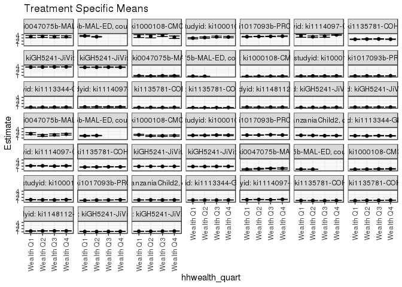

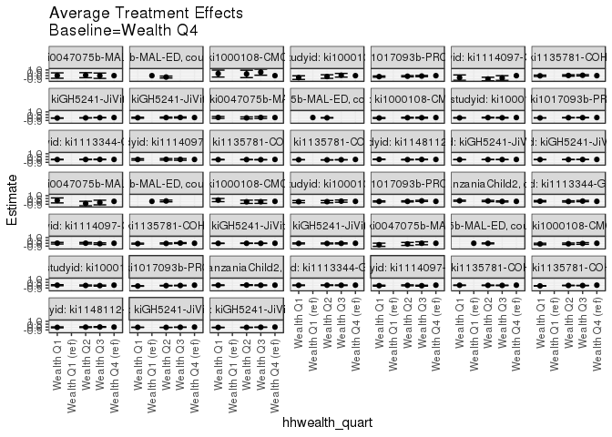

## Results Table

### Parameter: TSM

| agecat | studyid | country | intervention_level | baseline_level | estimate | ci_lower | ci_upper |
| --- | --- | --- | --- | --- | --- | --- | --- |
| 0-3 months | ki0047075b-MAL-ED | SOUTH AFRICA | Wealth Q4 | NA | 3.3990566 | 3.0992701 | 3.6988431 |
| 0-3 months | ki0047075b-MAL-ED | SOUTH AFRICA | Wealth Q1 | NA | 3.4183593 | 3.0509519 | 3.7857667 |
| 0-3 months | ki0047075b-MAL-ED | SOUTH AFRICA | Wealth Q2 | NA | 3.4791342 | 3.1529932 | 3.8052751 |
| 0-3 months | ki0047075b-MAL-ED | SOUTH AFRICA | Wealth Q3 | NA | 3.3881521 | 3.0238969 | 3.7524074 |
| 0-3 months | ki0047075b-MAL-ED | TANZANIA, UNITED REPUBLIC OF | Wealth Q1 | NA | 3.6397067 | 3.4981583 | 3.7812551 |
| 0-3 months | ki0047075b-MAL-ED | TANZANIA, UNITED REPUBLIC OF | Wealth Q2 | NA | 3.3919512 | 3.3013141 | 3.4825883 |
| 0-3 months | ki1000108-CMC-V-BCS-2002 | INDIA | Wealth Q4 | NA | 3.2286322 | 2.8326062 | 3.6246582 |
| 0-3 months | ki1000108-CMC-V-BCS-2002 | INDIA | Wealth Q1 | NA | 3.5931003 | 3.1289761 | 4.0572245 |
| 0-3 months | ki1000108-CMC-V-BCS-2002 | INDIA | Wealth Q2 | NA | 3.5323129 | 3.0151053 | 4.0495206 |
| 0-3 months | ki1000108-CMC-V-BCS-2002 | INDIA | Wealth Q3 | NA | 3.8418463 | 3.4853506 | 4.1983420 |
| 0-3 months | ki1000108-IRC | INDIA | Wealth Q4 | NA | 3.2831466 | 3.0468662 | 3.5194270 |
| 0-3 months | ki1000108-IRC | INDIA | Wealth Q1 | NA | 2.9382574 | 2.7252005 | 3.1513142 |
| 0-3 months | ki1000108-IRC | INDIA | Wealth Q2 | NA | 3.1294262 | 2.9166904 | 3.3421619 |
| 0-3 months | ki1000108-IRC | INDIA | Wealth Q3 | NA | 3.3553221 | 3.1299372 | 3.5807070 |
| 0-3 months | ki1017093b-PROVIDE | BANGLADESH | Wealth Q4 | NA | 3.5645408 | 3.4904959 | 3.6385856 |
| 0-3 months | ki1017093b-PROVIDE | BANGLADESH | Wealth Q1 | NA | 3.3982490 | 3.3162306 | 3.4802675 |
| 0-3 months | ki1017093b-PROVIDE | BANGLADESH | Wealth Q2 | NA | 3.4643214 | 3.3861307 | 3.5425122 |
| 0-3 months | ki1017093b-PROVIDE | BANGLADESH | Wealth Q3 | NA | 3.4964337 | 3.4192545 | 3.5736128 |
| 0-3 months | ki1114097-CONTENT | PERU | Wealth Q4 | NA | 3.9898145 | 3.8052975 | 4.1743315 |
| 0-3 months | ki1114097-CONTENT | PERU | Wealth Q1 | NA | 3.6471591 | 3.2148518 | 4.0794664 |
| 0-3 months | ki1114097-CONTENT | PERU | Wealth Q2 | NA | 3.4002936 | 3.1552176 | 3.6453696 |
| 0-3 months | ki1114097-CONTENT | PERU | Wealth Q3 | NA | 3.5733610 | 3.2070655 | 3.9396566 |
| 0-3 months | ki1135781-COHORTS | GUATEMALA | Wealth Q4 | NA | 2.5977458 | 2.5199206 | 2.6755710 |
| 0-3 months | ki1135781-COHORTS | GUATEMALA | Wealth Q1 | NA | 2.5703560 | 2.4790181 | 2.6616938 |
| 0-3 months | ki1135781-COHORTS | GUATEMALA | Wealth Q2 | NA | 2.6267206 | 2.5262680 | 2.7271731 |
| 0-3 months | ki1135781-COHORTS | GUATEMALA | Wealth Q3 | NA | 2.6617150 | 2.5757818 | 2.7476482 |
| 0-3 months | kiGH5241-JiVitA-3 | BANGLADESH | Wealth Q4 | NA | 3.7601797 | 3.7417911 | 3.7785683 |
| 0-3 months | kiGH5241-JiVitA-3 | BANGLADESH | Wealth Q1 | NA | 3.6775065 | 3.6584713 | 3.6965417 |
| 0-3 months | kiGH5241-JiVitA-3 | BANGLADESH | Wealth Q2 | NA | 3.7025981 | 3.6847389 | 3.7204573 |
| 0-3 months | kiGH5241-JiVitA-3 | BANGLADESH | Wealth Q3 | NA | 3.7384174 | 3.7209081 | 3.7559267 |

[output cut: 142 more lines]

### Parameter: E(Y)

| agecat | studyid | country | intervention_level | baseline_level | estimate | ci_lower | ci_upper |
| --- | --- | --- | --- | --- | --- | --- | --- |
| 0-3 months | ki0047075b-MAL-ED | SOUTH AFRICA | NA | NA | 3.4273613 | 3.2500085 | 3.6047141 |
| 0-3 months | ki0047075b-MAL-ED | TANZANIA, UNITED REPUBLIC OF | NA | NA | 3.5653800 | 3.3943198 | 3.7364403 |
| 0-3 months | ki1000108-CMC-V-BCS-2002 | INDIA | NA | NA | 3.5235318 | 3.3031217 | 3.7439420 |
| 0-3 months | ki1000108-IRC | INDIA | NA | NA | 3.1729204 | 3.0609523 | 3.2848884 |
| 0-3 months | ki1017093b-PROVIDE | BANGLADESH | NA | NA | 3.4826706 | 3.4434873 | 3.5218539 |
| 0-3 months | ki1114097-CONTENT | PERU | NA | NA | 3.6499227 | 3.4691077 | 3.8307378 |
| 0-3 months | ki1135781-COHORTS | GUATEMALA | NA | NA | 2.6146471 | 2.5705065 | 2.6587877 |
| 0-3 months | kiGH5241-JiVitA-3 | BANGLADESH | NA | NA | 3.7184677 | 3.7081242 | 3.7288113 |
| 0-3 months | kiGH5241-JiVitA-4 | BANGLADESH | NA | NA | 3.6386177 | 3.6075243 | 3.6697112 |
| 3-6 months | ki0047075b-MAL-ED | SOUTH AFRICA | NA | NA | 2.0417160 | 1.8774543 | 2.2059778 |
| 3-6 months | ki0047075b-MAL-ED | TANZANIA, UNITED REPUBLIC OF | NA | NA | 1.7369370 | 1.5843725 | 1.8895016 |
| 3-6 months | ki1000108-CMC-V-BCS-2002 | INDIA | NA | NA | 1.8037880 | 1.7029866 | 1.9045894 |
| 3-6 months | ki1000108-IRC | INDIA | NA | NA | 1.8806738 | 1.8168757 | 1.9444719 |
| 3-6 months | ki1017093b-PROVIDE | BANGLADESH | NA | NA | 1.9662173 | 1.9311292 | 2.0013054 |
| 3-6 months | ki1066203-TanzaniaChild2 | TANZANIA, UNITED REPUBLIC OF | NA | NA | 1.7933678 | 1.7575489 | 1.8291867 |
| 3-6 months | ki1113344-GMS-Nepal | NEPAL | NA | NA | 1.7057418 | 1.6666784 | 1.7448052 |
| 3-6 months | ki1114097-CONTENT | PERU | NA | NA | 2.0841841 | 2.0362519 | 2.1321163 |
| 3-6 months | ki1135781-COHORTS | GUATEMALA | NA | NA | 1.7591266 | 1.7281267 | 1.7901266 |
| 3-6 months | kiGH5241-JiVitA-3 | BANGLADESH | NA | NA | 1.9201827 | 1.9097195 | 1.9306459 |
| 3-6 months | kiGH5241-JiVitA-4 | BANGLADESH | NA | NA | 1.8987567 | 1.8688242 | 1.9286892 |
| 6-12 months | ki0047075b-MAL-ED | SOUTH AFRICA | NA | NA | 1.1843253 | 1.1031968 | 1.2654539 |
| 6-12 months | ki0047075b-MAL-ED | TANZANIA, UNITED REPUBLIC OF | NA | NA | 1.0152376 | 0.9345169 | 1.0959583 |
| 6-12 months | ki1000108-CMC-V-BCS-2002 | INDIA | NA | NA | 1.0624474 | 1.0146679 | 1.1102268 |
| 6-12 months | ki1000108-IRC | INDIA | NA | NA | 1.2485668 | 1.2193308 | 1.2778028 |
| 6-12 months | ki1017093b-PROVIDE | BANGLADESH | NA | NA | 1.1737150 | 1.1564064 | 1.1910236 |
| 6-12 months | ki1066203-TanzaniaChild2 | TANZANIA, UNITED REPUBLIC OF | NA | NA | 1.1966694 | 1.1750524 | 1.2182863 |
| 6-12 months | ki1113344-GMS-Nepal | NEPAL | NA | NA | 1.1681560 | 1.1485303 | 1.1877817 |
| 6-12 months | ki1114097-CONTENT | PERU | NA | NA | 1.3010517 | 1.2719491 | 1.3301542 |
| 6-12 months | ki1135781-COHORTS | GUATEMALA | NA | NA | 1.0171344 | 0.9996325 | 1.0346363 |
| 6-12 months | ki1135781-COHORTS | PHILIPPINES | NA | NA | 1.0674471 | 1.0552459 | 1.0796483 |
| 6-12 months | ki1148112-LCNI-5 | MALAWI | NA | NA | 1.2790810 | 1.2528925 | 1.3052695 |
| 6-12 months | kiGH5241-JiVitA-3 | BANGLADESH | NA | NA | 1.1069558 | 1.1002095 | 1.1137021 |
| 6-12 months | kiGH5241-JiVitA-4 | BANGLADESH | NA | NA | 1.2031603 | 1.1927643 | 1.2135564 |
| 12-24 months | ki0047075b-MAL-ED | SOUTH AFRICA | NA | NA | 0.8628601 | 0.8147601 | 0.9109601 |
| 12-24 months | ki0047075b-MAL-ED | TANZANIA, UNITED REPUBLIC OF | NA | NA | 0.7415304 | 0.6957036 | 0.7873573 |
| 12-24 months | ki1000108-CMC-V-BCS-2002 | INDIA | NA | NA | 0.7397013 | 0.7128622 | 0.7665404 |
| 12-24 months | ki1000108-IRC | INDIA | NA | NA | 0.8294859 | 0.8099817 | 0.8489901 |
| 12-24 months | ki1017093b-PROVIDE | BANGLADESH | NA | NA | 0.8575399 | 0.8455203 | 0.8695594 |
| 12-24 months | ki1113344-GMS-Nepal | NEPAL | NA | NA | 0.8378848 | 0.8224521 | 0.8533174 |
| 12-24 months | ki1114097-CONTENT | PERU | NA | NA | 0.9259464 | 0.8927736 | 0.9591191 |
| 12-24 months | ki1135781-COHORTS | GUATEMALA | NA | NA | 0.7790712 | 0.7681227 | 0.7900197 |
| 12-24 months | ki1135781-COHORTS | PHILIPPINES | NA | NA | 0.7067500 | 0.6994129 | 0.7140870 |
| 12-24 months | ki1148112-LCNI-5 | MALAWI | NA | NA | 0.8407809 | 0.8238743 | 0.8576875 |
| 12-24 months | kiGH5241-JiVitA-3 | BANGLADESH | NA | NA | 0.7967251 | 0.7914074 | 0.8020427 |
| 12-24 months | kiGH5241-JiVitA-4 | BANGLADESH | NA | NA | 0.8492263 | 0.8437928 | 0.8546597 |

### Parameter: ATE

| agecat | studyid | country | intervention_level | baseline_level | estimate | ci_lower | ci_upper |
| --- | --- | --- | --- | --- | --- | --- | --- |
| 0-3 months | ki0047075b-MAL-ED | SOUTH AFRICA | Wealth Q4 | Wealth Q4 | 0.0000000 | 0.0000000 | 0.0000000 |
| 0-3 months | ki0047075b-MAL-ED | SOUTH AFRICA | Wealth Q1 | Wealth Q4 | 0.0193027 | -0.4548915 | 0.4934969 |
| 0-3 months | ki0047075b-MAL-ED | SOUTH AFRICA | Wealth Q2 | Wealth Q4 | 0.0800776 | -0.3629121 | 0.5230673 |
| 0-3 months | ki0047075b-MAL-ED | SOUTH AFRICA | Wealth Q3 | Wealth Q4 | -0.0109045 | -0.4826606 | 0.4608517 |
| 0-3 months | ki0047075b-MAL-ED | TANZANIA, UNITED REPUBLIC OF | Wealth Q1 | Wealth Q1 | 0.0000000 | 0.0000000 | 0.0000000 |
| 0-3 months | ki0047075b-MAL-ED | TANZANIA, UNITED REPUBLIC OF | Wealth Q2 | Wealth Q1 | -0.2477555 | -0.4158360 | -0.0796751 |
| 0-3 months | ki1000108-CMC-V-BCS-2002 | INDIA | Wealth Q4 | Wealth Q4 | 0.0000000 | 0.0000000 | 0.0000000 |
| 0-3 months | ki1000108-CMC-V-BCS-2002 | INDIA | Wealth Q1 | Wealth Q4 | 0.3644681 | -0.2456531 | 0.9745893 |
| 0-3 months | ki1000108-CMC-V-BCS-2002 | INDIA | Wealth Q2 | Wealth Q4 | 0.3036807 | -0.3477334 | 0.9550948 |
| 0-3 months | ki1000108-CMC-V-BCS-2002 | INDIA | Wealth Q3 | Wealth Q4 | 0.6132141 | 0.0803672 | 1.1460609 |
| 0-3 months | ki1000108-IRC | INDIA | Wealth Q4 | Wealth Q4 | 0.0000000 | 0.0000000 | 0.0000000 |
| 0-3 months | ki1000108-IRC | INDIA | Wealth Q1 | Wealth Q4 | -0.3448893 | -0.6630428 | -0.0267358 |
| 0-3 months | ki1000108-IRC | INDIA | Wealth Q2 | Wealth Q4 | -0.1537204 | -0.4716590 | 0.1642181 |
| 0-3 months | ki1000108-IRC | INDIA | Wealth Q3 | Wealth Q4 | 0.0721755 | -0.2543621 | 0.3987130 |
| 0-3 months | ki1017093b-PROVIDE | BANGLADESH | Wealth Q4 | Wealth Q4 | 0.0000000 | 0.0000000 | 0.0000000 |
| 0-3 months | ki1017093b-PROVIDE | BANGLADESH | Wealth Q1 | Wealth Q4 | -0.1662918 | -0.2767891 | -0.0557944 |
| 0-3 months | ki1017093b-PROVIDE | BANGLADESH | Wealth Q2 | Wealth Q4 | -0.1002193 | -0.2079061 | 0.0074674 |
| 0-3 months | ki1017093b-PROVIDE | BANGLADESH | Wealth Q3 | Wealth Q4 | -0.0681071 | -0.1750616 | 0.0388474 |
| 0-3 months | ki1114097-CONTENT | PERU | Wealth Q4 | Wealth Q4 | 0.0000000 | 0.0000000 | 0.0000000 |
| 0-3 months | ki1114097-CONTENT | PERU | Wealth Q1 | Wealth Q4 | -0.3426554 | -0.8126938 | 0.1273830 |
| 0-3 months | ki1114097-CONTENT | PERU | Wealth Q2 | Wealth Q4 | -0.5895209 | -0.8962924 | -0.2827494 |
| 0-3 months | ki1114097-CONTENT | PERU | Wealth Q3 | Wealth Q4 | -0.4164535 | -0.8265985 | -0.0063084 |
| 0-3 months | ki1135781-COHORTS | GUATEMALA | Wealth Q4 | Wealth Q4 | 0.0000000 | 0.0000000 | 0.0000000 |
| 0-3 months | ki1135781-COHORTS | GUATEMALA | Wealth Q1 | Wealth Q4 | -0.0273898 | -0.1473872 | 0.0926075 |
| 0-3 months | ki1135781-COHORTS | GUATEMALA | Wealth Q2 | Wealth Q4 | 0.0289748 | -0.0980980 | 0.1560475 |
| 0-3 months | ki1135781-COHORTS | GUATEMALA | Wealth Q3 | Wealth Q4 | 0.0639692 | -0.0519673 | 0.1799057 |
| 0-3 months | kiGH5241-JiVitA-3 | BANGLADESH | Wealth Q4 | Wealth Q4 | 0.0000000 | 0.0000000 | 0.0000000 |
| 0-3 months | kiGH5241-JiVitA-3 | BANGLADESH | Wealth Q1 | Wealth Q4 | -0.0826732 | -0.1085052 | -0.0568412 |
| 0-3 months | kiGH5241-JiVitA-3 | BANGLADESH | Wealth Q2 | Wealth Q4 | -0.0575816 | -0.0824708 | -0.0326924 |
| 0-3 months | kiGH5241-JiVitA-3 | BANGLADESH | Wealth Q3 | Wealth Q4 | -0.0217623 | -0.0456861 | 0.0021616 |

[output cut: 142 more lines]